# Shotgun Vs. 16S Gardnerella variants

Hanna Berman

12/10/2019

# Set up

## packages

```r
library(tidyverse)
library(phyloseq)
library(Biostrings)
```

## Paths

```r
repo_dir <- "/Users/hlberman/Documents/GitHub/pregnancy_metagenome/"

#shotgun metadata
sgDF <- file.path(repo_dir, "shotgunMetadata.tsv") %>%
  read_delim(delim = "\t") %>%
  mutate(SampleID=as.character(SampleID),
         SampleID_a=as.character(SampleID_a))
#ASVs from Callahan et al., 2017
S16_path <- "/Volumes/GoogleDrive/My Drive/Callahan Lab/vagMicrobiomeMetagenome/16S_data/RepRefine_Scripts/input/processed.rda"
load(S16_path)

#Gardnerella 16S fasta sequences from reference WGS strains
rRNAs16S <- readDNAStringSet(file.path(repo_dir, "gard_mapping", "clade_assignments", "16SrRNAs.fasta"))

#gardnerella metadata
refDF <- file.path(repo_dir, "GardnerellaMetadata.csv") %>%
  read_csv
#Gardnerella abundance from shotgun results
sgGardDF <- "./gardRelativeAbundance.tsv" %>%
  read_tsv() %>%
  mutate(SampleID=as.character(SampleID))
```

```r
#figure_out <- "/Volumes/GoogleDrive/My Drive/Callahan Lab/vagMicrobiomeMetagenome/gardMapping/clade_assignments/figures"
```

Set up metaphlan table

```r
#metaphlan data
mDF0 <- file.path("/Volumes/GoogleDrive/My Drive/Callahan Lab/vagMicrobiomeMetagenome/humann2/merged_tables/mergedMetaphlanAbundance.tsv") %>%
  read_tsv() %>%
  filter(str_detect(ID, "s__"), !str_detect(ID, "t__")) %>%
  mutate(Species = str_extract(ID, "(?<=s__)\\w+$")) %>%
  select(Species, everything(), -ID) %>%
  as.data.frame()
#make col and row names
samps <- colnames(mDF0[2:ncol(mDF0)]) %>%
  str_extract("[0-9]{10}")
samps
```

```
##   [1] "1000801248" "1000801318" "1000801368" "1001301158" "1001301248"
##   [6] "1001301318" "1001801138" "1001801248" "1001801318" "1002701138"
##  [11] "1002701158" "1002701278" "1003101118" "1003101188" "1003101278"
##  [16] "1004001168" "1004001278" "1004001348" "1005601098" "1005601168"
##  [21] "1005601348" "1050801308" "1050801318" "1050835178" "1050835218"
##  [26] "1060435158" "1060435318" "1060435348" "1060801198" "1060801338"
##  [31] "1060835148" "1061235118" "1061235188" "1061235278" "1061635088"
##  [36] "1061635208" "1061635368" "1062101108" "1062101238" "1062101338"
##  [41] "1062301128" "1062301198" "1062335178" "1062601228" "1062601258"
##  [46] "1062601368" "1062701128" "1062701298" "1062735148" "1062735198"
##  [51] "1062901138" "1062901218" "1062901318" "1900401198" "1900401288"
##  [56] "1900401398" "1902401118" "1902401208" "1902401308" "2050501168"
##  [61] "2050501298" "2050501348" "4002101198" "4002101298" "4002135018"
##  [66] "4003235018" "4003235288" "4003235368" "4004235208" "4004235248"
##  [71] "4004235268" "4004735328" "4004735368" "4004935158" "4004935268"
##  [76] "4004935338" "4005935278" "4005935328" "4005935358" "4006635198"
##  [81] "4006635258" "4006635278" "4006635338" "4006935208" "4006935248"
##  [86] "4006935358" "4007135108" "4007135118" "4007135148" "4007135288"
##  [91] "4007235168" "4007235278" "4007435168" "4007435248" "4007435258"
##  [96] "4007535198" "4007535238" "4007535358" "4008435158" "4008435348"
## [101] "4008435358" "4009035168" "4009035268" "4009035368" "4009835178"
## [106] "4009835228" "4009835268"
```

```r
colnames(mDF0) <- c("Species", samps)
rownames(mDF0) <- mDF0$Species

#Final edits to table
mDF <- mDF0 %>%
  select(-Species) %>%
  t() %>%
  as_tibble() %>%
  mutate_all(funs(./100)) %>%
  mutate(SampleID=samps) %>%
  select(SampleID, everything())
mDF[1:6,1:5]
```

```
## # A tibble: 6 x 5
##   SampleID Actinobaculum_m… Actinobaculum_s… Actinobaculum_u…
##   <chr>               <dbl>            <dbl>            <dbl>
## 1 1000801…                0                0                0
## 2 1000801…                0                0                0
## 3 1000801…                0                0                0
## 4 1001301…                0                0                0
## 5 1001301…                0                0                0
## 6 1001301…                0                0                0
## # … with 1 more variable: Actinomyces_europaeus <dbl>
```

# Get variants

```r
studyIDs <- sgDF$SampleID_a

PS17 <- phyloseq(otu_table(st, taxa_are_rows=FALSE), sample_data(df), tax_table(tax))
  #transform_sample_counts(function(x) {x/sum(x)}) #make read counts into relative abundances

has.shotgun <- PS17@sam_data$SampleID %in% studyIDs
PS16S_170 <- PS17 %>%
  subset_samples(has.shotgun) #keep only samples of interest in OTU table

# sgDF0 <- sgDF %>%
#  filter(PaperCohort==2017) %>%
#  mutate(SampleID=as.character(SampleID),
#         SampleID_a=as.character(SampleID_a))

gardVarTable <- PS16S_170 %>%
  psmelt() %>%
  dplyr::rename(SampleID_a = SampleID) %>%
  filter(Genus=="Gardnerella",
         Abundance>0) %>%
  left_join(., sgDF[,c("SampleID_a", "SampleID", "RNAlater")], by="SampleID_a")
```

Note: there are 9 variants among the entire sample set for 2017, but only 5 within these 81 samples

## Function to get the variants among all sequences

```r
varSequences <- function(label, sequences){
  sequenceVariants <- unique(sequences)
  names(sequenceVariants) <- paste(label, c(1:length(sequenceVariants)), sep =  "_")
  print(sequenceVariants)
}
```

## Relate Variant assignments to clades

```r
vars <- as.list(varSequences("G", gardVarTable$OTU)) # get list of variants from 16S march of dimes
```

```
##                                                                                                                                                                                                                                           G_1
## "GCAAGCGTTATCCGGAATTATTGGGCGTAAAGAGCTTGTAGGCGGTTCGTCGCGTCTGGT…"
##                                                                                                                                                                                                                                           G_2
## "GCAAGCGTTATCCGGAATTATTGGGCGTAAAGAGCTTGTAGGCGGTTCGTCGCGTCTGGT…"
##                                                                                                                                                                                                                                           G_3
## "GCAAGCGTTATCCGGAATTATTGGGCGTAAAGAGCTTGTAGGCGGTTCGTCGCGTCTGGT…"
##                                                                                                                                                                                                                                           G_4
## "GCAAGCGTTATCCGGATTTATTGGGCGTAAAGAGCTTGTAGGCGGTTCGTCGCGTCTGGT…"
##                                                                                                                                                                                                                                           G_5
## "GCAAGCGTTATCCGGAATTATTGGGCGTAAAGAGCTTGTAGGCGGTTCGTCGCGTCTGGT…"
```

```r
strains <- names(rRNAs16S) %>%
  str_extract(., ".*(?=_[0-9]{5} 16S ribosomal RNA$)")
varClades <- vars %>%
  map(.,~vcountPattern(.x, rRNAs16S)) %>%
  data.frame(Strain=strains) %>%
  mutate(Var=case_when(G_1==1~"G1",
                       G_2==1~"G2",
                       G_3==1~"G3",
                       G_4==1~"G4",
                       G_5==1~"G5")) %>%
  left_join(refDF[,c("Strain", "Clade")], by="Strain") %>%
  select(Var, Clade) %>%
  mutate(Clade=as.character(Clade)) %>%
  unique()
varClades
```

```
##     Var Clade
## 1    G1    C2
## 3    G2    C3
## 4  <NA>    C1
## 5    G1    C1
## 7    G3    C1
## 12   G2    C4
## 32   G4    C5
## 38   G3    C2
## 43   G5    C6
## 45   G3    C3
```

**NOTE: THESE LABELS DO NOT MATCH Callahan 2017 G1/G2 ARE FLIPPED**

## classify samples

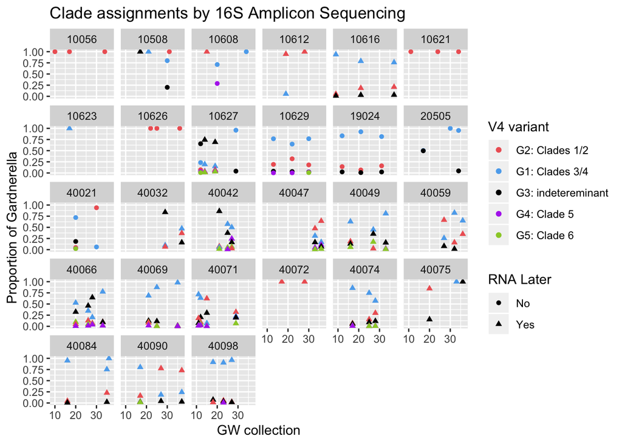

```r
S16gardDF <- gardVarTable %>%
  mutate(Var=case_when(OTU==vars$G_1~"G2: Clades 1/2", #change G1/G2 to match Callahan 2017
                        OTU==vars$G_2~"G1: Clades 3/4",
                        OTU==vars$G_3~"G3: indetereminant",
                        OTU==vars$G_4~"G4: Clade 5",
                        OTU==vars$G_5~"G5: Clade 6")) %>%
  group_by(SampleID) %>%
  mutate(propGard=Abundance/sum(Abundance)) %>%
  ungroup() %>%
  select(OTU, SampleID, SubjectID, Abundance, propGard, GWcoll, RNAlater, Var)
S16gardDF$Var <- factor(S16gardDF$Var, levels = c("G2: Clades 1/2", "G1: Clades 3/4", "G3: indetereminant", "G4: Clade 5", "G5: Clade 6")) #Keep order G2, G1, G3, G4, G5

ggplot(data=S16gardDF, aes(x=GWcoll, y=propGard, color=Var, shape=RNAlater)) +
  geom_point() +
  facet_wrap(~SubjectID) +
  scale_color_manual(values=c("indianred2", "steelblue2", "black", "darkorchid2", "yellowgreen")) + # labels=c("G2: Clades 1/2", "G1: Clades 3/4", "G3: indetereminant", "G4: Clade 5", "G5: Clade 6")) +
  labs(title = "Clade assignments by 16S Amplicon Sequencing", x= "GW collection", y="Proportion of Gardnerella", shape="RNA Later", color="V4 variant")
```

```r
#ggsave(filename = file.path(figure_out, "cladesBy16S.pdf"))
```

## Save table

```r
#write_delim(S16gardDF, "./16SgardVariants.tsv", delim="\t")
```

# Comparison to shotgun methods:

## Unify dataframe

```r
S16gardDF0 <- S16gardDF %>%
  select(SampleID, Var, propGard) %>%
  mutate(Method="V4 region 16S amplicon")

sgGardDF0 <- sgGardDF %>%
#  select(-n) %>%
  dplyr::rename(Var=Clade,
                propGard=propClade) %>%
  mutate(Var=case_when(Var=="C1"~"Clade 1",
                       Var=="C2"~"Clade 2",
                       Var=="C3"~"Clade 3",
                       Var=="C4"~"Clade 4",
                       Var=="C5"~"Clade 5",
                       Var=="C6"~"Clade 6"),
         Method="Shotgun")

gardVarDF <- S16gardDF0 %>%
  full_join(sgGardDF0, by=c("SampleID", "Var", "propGard", "Method")) %>%
  left_join(sgDF[,c("SampleID", "SubjectID", "GWcoll", "RNAlater", "PaperCohort")], by="SampleID")
gardVarDF$Var <- factor(gardVarDF$Var, levels=c("Clade 1", "Clade 2", "Clade 3", "Clade 4", "Clade 5", "Clade 6", "G2: Clades 1/2", "G1: Clades 3/4", "G3: indetereminant", "G4: Clade 5", "G5: Clade 6"))
```

## Plot

Subset of two samples

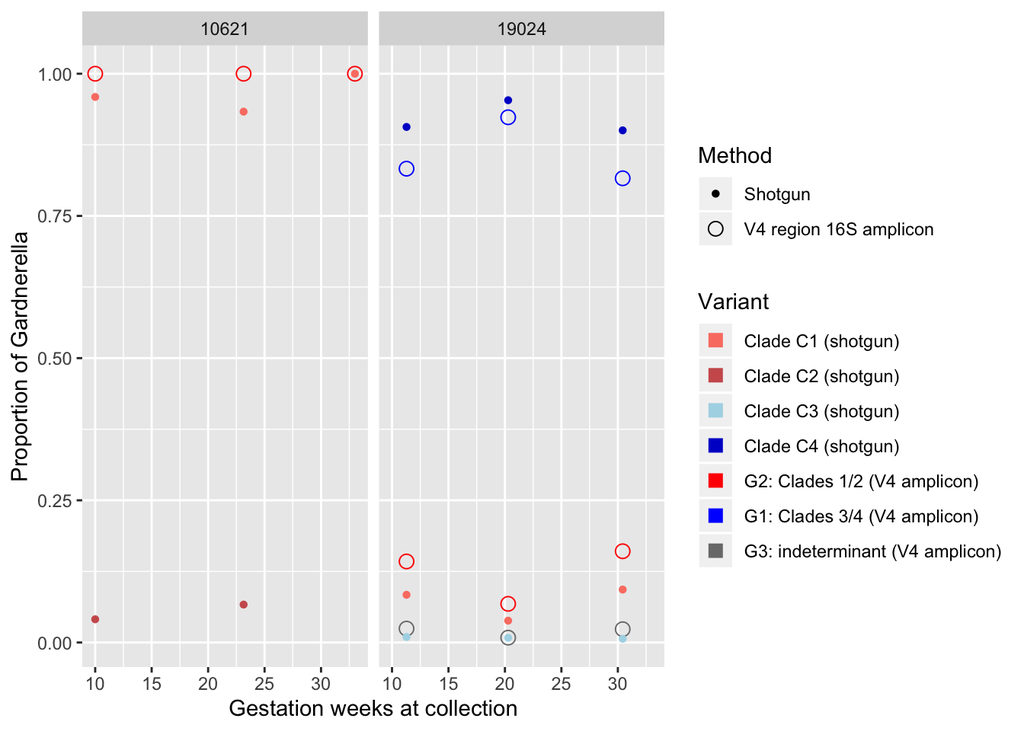

```r
gardVarDF %>%
  filter(RNAlater=="No",
         SubjectID=="10621"|SubjectID=="19024")%>%
ggplot(aes(x=GWcoll, y=propGard, color=Var, shape=Method, size=Method)) +
  geom_point() +
  scale_size_manual(values=c(1.5, 3)) +
  scale_color_manual(values=c("salmon", "indianred", "lightblue", "blue3", "red", "blue1", "grey48"), labels=c("Clade C1 (shotgun)", "Clade C2 (shotgun)", "Clade C3 (shotgun)", "Clade C4 (shotgun)", "G2: Clades 1/2 (V4 amplicon)", "G1: Clades 3/4 (V4 amplicon)", "G3: indeterminant (V4 amplicon)")) +
  scale_shape_manual(values = c(16, 1)) +
  facet_wrap(~SubjectID) +
  labs(x="Gestation weeks at collection", y="Proportion of Gardnerella", shape="Method", color="Variant") +
  guides(color=guide_legend(override.aes=list(shape=15, size=3)))
```

```r
#ggsave(file.path(figure_out, "biolunchV4SG2samp.png"), width=8, height=6)
```

All samples

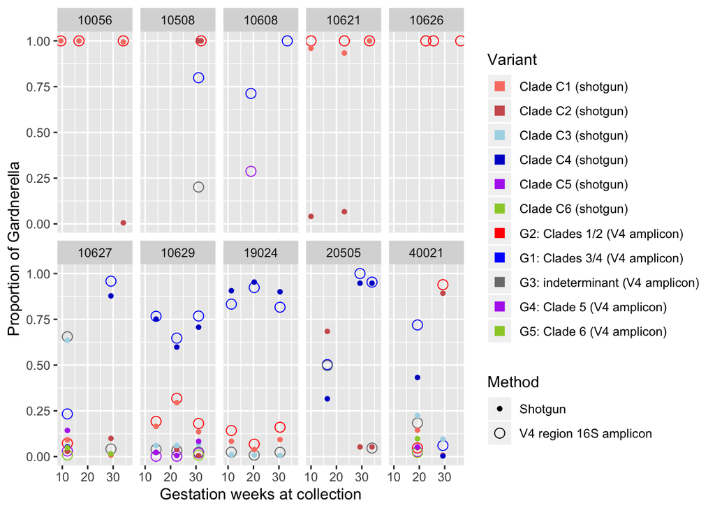

```r
gardVarDF %>%
  filter(RNAlater=="No",
         PaperCohort==2017)%>%
ggplot(aes(x=GWcoll, y=propGard, shape=Method, size=Method, color=Var)) +
  geom_point() +
  scale_size_manual(values=c(1.5, 3)) +
  scale_color_manual(values=c("salmon", "indianred", "lightblue", "blue3", "darkorchid2", "yellowgreen", "red", "blue1", "grey48", "darkorchid2", "yellowgreen"), labels=c("Clade C1 (shotgun)", "Clade C2 (shotgun)", "Clade C3 (shotgun)", "Clade C4 (shotgun)", "Clade C5 (shotgun)", "Clade C6 (shotgun)", "G2: Clades 1/2 (V4 amplicon)", "G1: Clades 3/4 (V4 amplicon)", "G3: indeterminant (V4 amplicon)", "G4: Clade 5 (V4 amplicon)", "G5: Clade 6 (V4 amplicon)")) +
  scale_shape_manual(values = c(16, 1)) +
  facet_wrap(~SubjectID, nrow=2) +
  labs(x="Gestation weeks at collection", y="Proportion of Gardnerella", shape="Method", color="Variant") +
  guides(color=guide_legend(override.aes=list(shape=15, size=3)))
```

```r
#ggsave(file.path(figure_out, "biolunchV4SGv1.png"), width=8, height=6)
```

# Add thresholds and test:

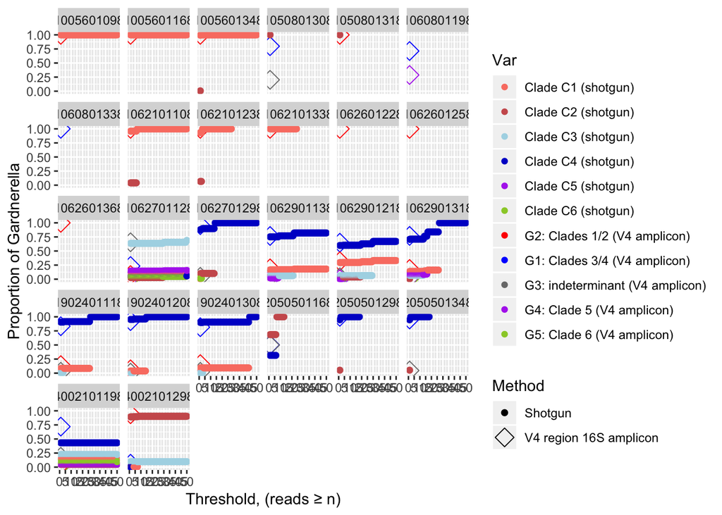

```r
# create data frames
thresholds <- c(1:49) %>% # set the threshold range
  map(~filter(gardVarDF, n>.x)) %>% # filter out clades below read threshold
  map(~group_by(.x, SampleID)) %>%
  map(~mutate(.x, propGard=propGard/sum(propGard))) %>% # recalculate proportions after threshold filtering
  map(ungroup) %>%
  map2(c(1:49), ~mutate(.x, Threshold=.y)) %>% # add threshold column
  purrr::reduce(full_join, by=c(colnames(gardVarDF), "Threshold")) # reduce to one data frame

# add threshold information to data frame
gardVarDF0 <- gardVarDF %>%
  mutate(Threshold=0) %>% # set zero threshold for baseline
  rbind(thresholds) %>%
  mutate(Threshold=Threshold+1) # make threshold as >=n

# plot
gardVarDF0 %>%
  filter(RNAlater=="No", PaperCohort=="2017") %>%
  ggplot(aes(x=Threshold, y=propGard, shape=Method, size=Method, color=Var)) +
  geom_point() +
  scale_size_manual(values=c(2, 4)) +
  scale_shape_manual(values = c(16, 5)) +
  scale_color_manual(values=c("salmon", "indianred", "lightblue", "blue3", "darkorchid2", "yellowgreen", "red", "blue1", "grey48", "darkorchid2", "yellowgreen"), labels=c("Clade C1 (shotgun)", "Clade C2 (shotgun)", "Clade C3 (shotgun)", "Clade C4 (shotgun)", "Clade C5 (shotgun)", "Clade C6 (shotgun)", "G2: Clades 1/2 (V4 amplicon)", "G1: Clades 3/4 (V4 amplicon)", "G3: indeterminant (V4 amplicon)", "G4: Clade 5 (V4 amplicon)", "G5: Clade 6 (V4 amplicon)")) +
  ylim(0,1) +
  scale_x_continuous(breaks = seq(0,50, 5)) +
  facet_wrap(~SampleID) +
  labs(x="Threshold, (reads ≥ n)", y="Proportion of Gardnerella")
```

Look at distribution of clades per sample after threshold filtering

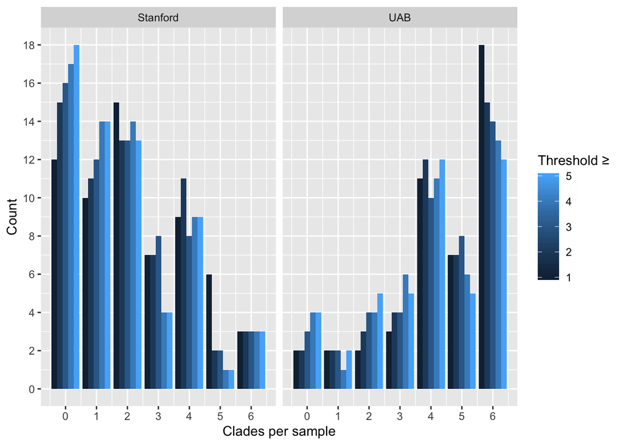

```r
# 1 to 5
add0s <- tibble(SampleID=rep(sgDF$SampleID, 5),
               Threshold=c(rep(1, 107), rep(2, 107), rep(3, 107), rep(4, 107), rep(5, 107)))

gardVarDF0 %>%
  filter(Method == "Shotgun") %>%
  filter(Threshold %in% c(1:5)) %>%
  group_by(Threshold, SampleID) %>%
  summarise(nClades=n()) %>%
  full_join(add0s, by=c("SampleID", "Threshold")) %>% #each sample has 5 entries (1 per threshold)
  mutate(nClades=replace_na(nClades, 0)) %>% #replace NAs with 0's
  left_join(sgDF[,c("SampleID", "Cohort")]) %>%
  ggplot(aes(x=nClades, group=Threshold, fill=Threshold)) +
  geom_bar(stat="count", position="dodge") +
  facet_wrap(~Cohort) +
  scale_x_continuous(breaks=seq(0,6,1)) +
  scale_y_continuous(breaks=seq(0,20,2)) +
  labs(x="Clades per sample", y="Count", fill="Threshold ≥")
```

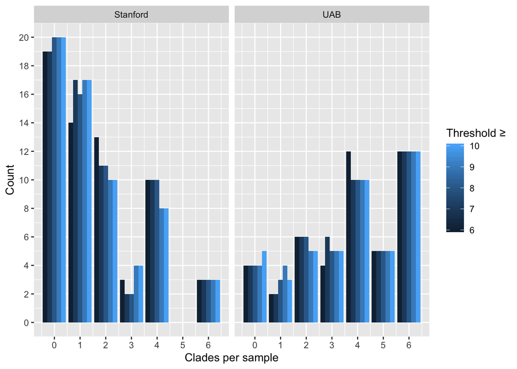

```r
add0s <- tibble(SampleID=rep(sgDF$SampleID, 5),
               Threshold=c(rep(6, 107), rep(7, 107), rep(8, 107), rep(9, 107), rep(10, 107)))

#6 to 10
gardVarDF0 %>%
  filter(Method == "Shotgun") %>%
  filter(Threshold %in% c(6:10)) %>%
  group_by(Threshold, SampleID) %>%
  summarise(nClades=n()) %>%
  full_join(add0s, by=c("SampleID", "Threshold")) %>% #each sample has 5 entries (1 per threshold)
  mutate(nClades=replace_na(nClades, 0)) %>% #replace NAs with 0's
  left_join(sgDF[,c("SampleID", "Cohort")]) %>%
  ggplot(aes(x=nClades, group=Threshold, fill=Threshold)) +
  geom_bar(stat="count", position="dodge") +
  facet_wrap(~Cohort) +
  scale_x_continuous(breaks=seq(0,6,1)) +
  scale_y_continuous(breaks=seq(0,20,2)) +
  labs(x="Clades per sample", y="Count", fill="Threshold ≥")
```

```r
sapply(list(ReadDepth=sgDF$TotalPairs, inputReads=sgDF$upload_pairs, bbmapFiltered=sgDF$bbmapFiltered_pairs), summary)
```

```
##         ReadDepth inputReads bbmapFiltered
## Min.     13081280    4425640         45290
## 1st Qu.  16989480   12244589        373054
## Median   18701853   13393606       1569454
## Mean     19495546   13704837       2824539
## 3rd Qu.  21206328   15325243       4541656
## Max.     35557864   26027294      17576676
```

```r
meanDepth <- mean(sgDF$TotalPairs)
meanDepth
```

```
## [1] 19495546
```

```r
meanInput <- mean(sgDF$bbmapFiltered_pairs)
meanInput
```

```
## [1] 2824539
```

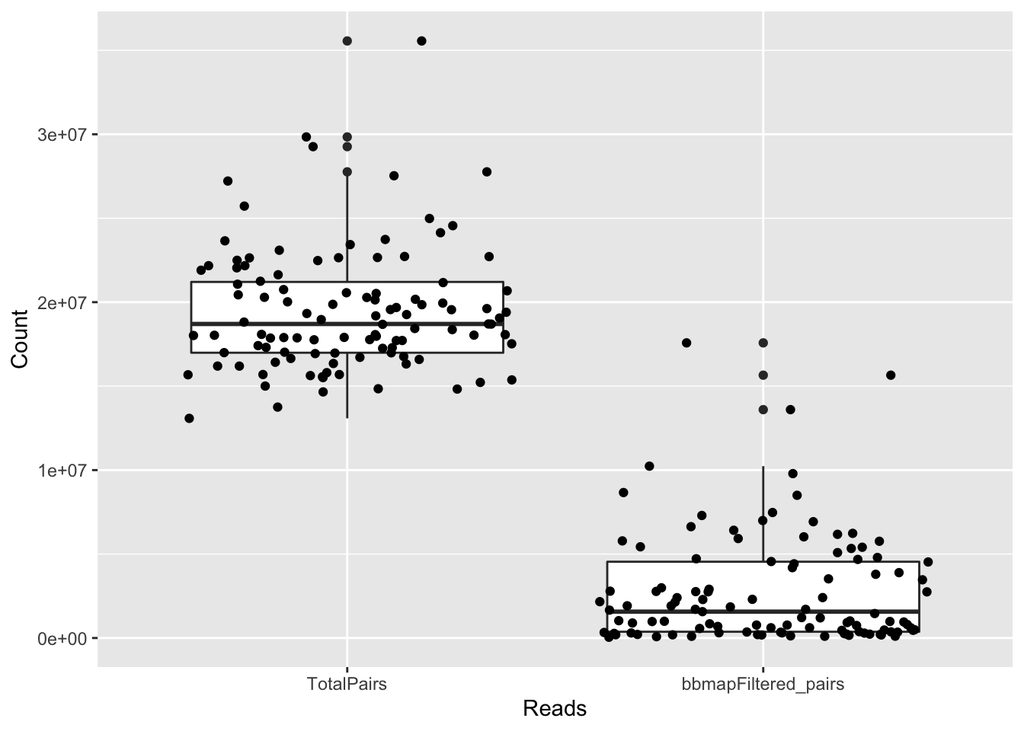

```r
sgDF0 <- sgDF %>%
  select(TotalPairs, bbmapFiltered_pairs) %>%
  gather("Reads", "Count", c(1:2))
sgDF0$Reads <- factor(sgDF0$Reads, levels=c("TotalPairs", "bbmapFiltered_pairs"))

ggplot(data=sgDF0, aes(y=Count, x=Reads)) +
  geom_boxplot() +
  geom_jitter()
```

## Samples where we lose all Gardnerella

In subject 10608: No Gardnerella was detected. Shotgun sequencing can demonstrate less sensitivity than amplicon sequencing.  
In subject 10626: Some Gardnerella was detected (by metaphlan), but we do not see any after filtering the reads with our criteria.  
**Sample 10608**

```r
#gardnerella found by metaphlan in subject 10608
gardVarDF %>%
  filter(SubjectID==10608,
         RNAlater=="No") %>%
  select(SampleID, Var, propGard, Method)
```

```
## # A tibble: 3 x 4
##   SampleID   Var            propGard Method
##   <chr>      <fct>             <dbl> <chr>
## 1 1060801198 G1: Clades 3/4    0.713 V4 region 16S amplicon
## 2 1060801198 G4: Clade 5       0.287 V4 region 16S amplicon
## 3 1060801338 G1: Clades 3/4    1     V4 region 16S amplicon
```

```r
samples10608 <- gardVarDF %>%
  filter(SubjectID==10608,
         RNAlater=="No") %>%
  .$SampleID %>%
  unique
samples10608
```

```
## [1] "1060801198" "1060801338"
```

```r
#percent Gardnerella in these samples
mDF %>%
  select(SampleID, Gardnerella_vaginalis) %>%
  filter(SampleID %in% samples10608)
```

```
## # A tibble: 2 x 2
##   SampleID   Gardnerella_vaginalis
##   <chr>                      <dbl>
## 1 1060801198                     0
## 2 1060801338                     0
```

```r
#read depth of these samples
sgDF %>%
  filter(SampleID %in% samples10608) %>%
  select(SampleID, TotalPairs, bbmapFiltered_pairs, finalPctHuman_po)
```

```
## # A tibble: 2 x 4
##   SampleID   TotalPairs bbmapFiltered_pairs finalPctHuman_po
##   <chr>           <dbl>               <dbl>            <dbl>
## 1 1060801198   14655421              258848            0.980
## 2 1060801338   15223063              195122            0.985
```

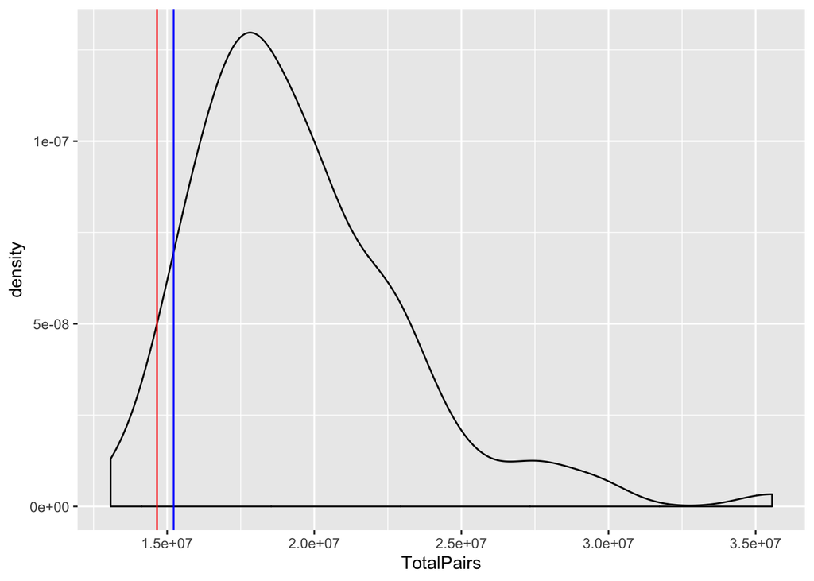

```r
ggplot(data=sgDF) +
  geom_density(aes(x=TotalPairs)) +
  geom_vline(xintercept = sgDF$TotalPairs[sgDF$SampleID==samples10608[1]], color="red") +
  geom_vline(xintercept = sgDF$TotalPairs[sgDF$SampleID==samples10608[2]], color="blue")
```

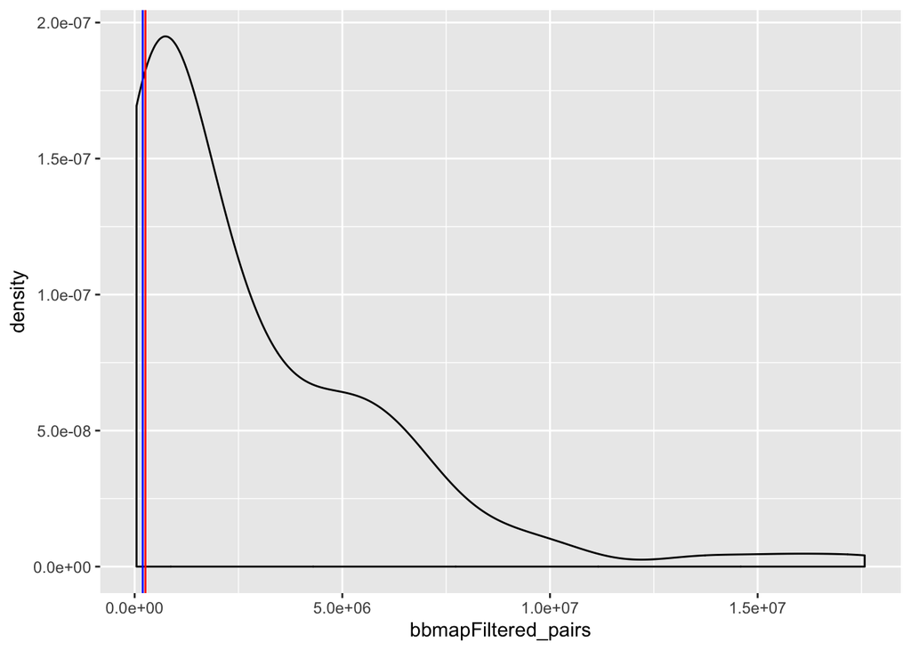

```r
ggplot(data=sgDF) +
  geom_density(aes(x=bbmapFiltered_pairs)) +
  geom_vline(xintercept = sgDF$bbmapFiltered_pairs[sgDF$SampleID==samples10608[1]], color="red") +
  geom_vline(xintercept = sgDF$bbmapFiltered_pairs[sgDF$SampleID==samples10608[2]], color="blue")
```

**Sample 10626**

```r
#gardnerella found by metaphlan in subject 10626
gardVarDF %>%
  filter(SubjectID==10626,
         RNAlater=="No") %>%
  select(SampleID, Var, propGard, Method)
```

```
## # A tibble: 3 x 4
##   SampleID   Var            propGard Method
##   <chr>      <fct>             <dbl> <chr>
## 1 1062601228 G2: Clades 1/2        1 V4 region 16S amplicon
## 2 1062601258 G2: Clades 1/2        1 V4 region 16S amplicon
## 3 1062601368 G2: Clades 1/2        1 V4 region 16S amplicon
```

```r
samples10626 <- gardVarDF %>%
  filter(SubjectID==10626,
         RNAlater=="No") %>%
  .$SampleID %>%
  unique
samples10626
```

```
## [1] "1062601228" "1062601258" "1062601368"
```

```r
#percent Gardnerella in these samples
mDF %>%
  select(SampleID, Gardnerella_vaginalis) %>%
  filter(SampleID %in% samples10626)
```

```
## # A tibble: 3 x 2
##   SampleID   Gardnerella_vaginalis
##   <chr>                      <dbl>
## 1 1062601228                0.179
## 2 1062601258                0.0692
## 3 1062601368                0.0204
```

```r
#read depth of these samples
sgDF %>%
  filter(SampleID %in% samples10626) %>%
  select(SampleID, TotalPairs, bbmapFiltered_pairs, PctHuman, finalPctHuman_po)
```

```
## # A tibble: 3 x 5
##   SampleID   TotalPairs bbmapFiltered_pairs PctHuman finalPctHuman_po
##   <chr>           <dbl>               <dbl>    <dbl>            <dbl>
## 1 1062601258   14825102               45290    0.497            0.996
## 2 1062601368   17521686              311168    0.479            0.980
## 3 1062601228   22477526              107838    0.503            0.994
```

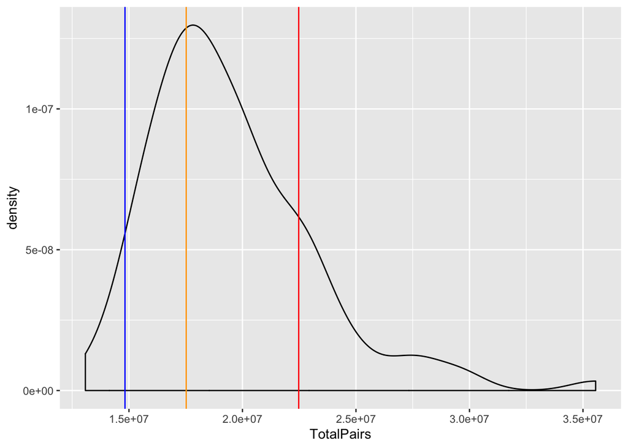

```r
ggplot(data=sgDF) +
  geom_density(aes(x=TotalPairs)) +
  geom_vline(xintercept = sgDF$TotalPairs[sgDF$SampleID==samples10626[1]], color="red") +
  geom_vline(xintercept = sgDF$TotalPairs[sgDF$SampleID==samples10626[2]], color="blue") +
  geom_vline(xintercept = sgDF$TotalPairs[sgDF$SampleID==samples10626[3]], color="orange")
```

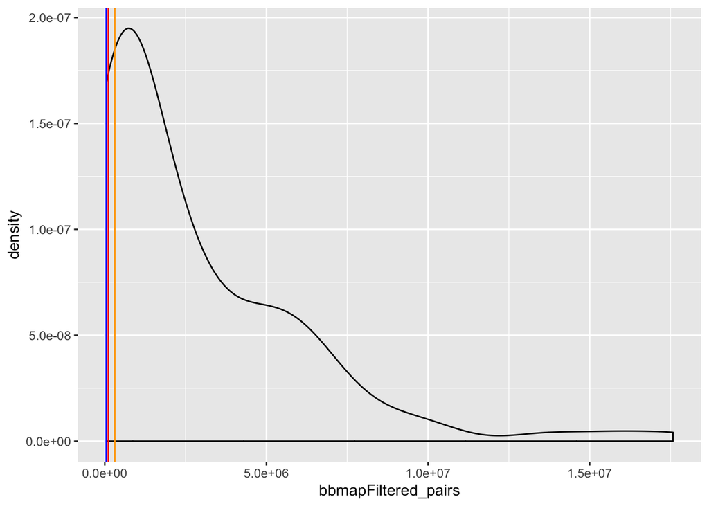

```r
ggplot(data=sgDF) +
  geom_density(aes(x=bbmapFiltered_pairs)) +
  geom_vline(xintercept = sgDF$bbmapFiltered_pairs[sgDF$SampleID==samples10626[1]], color="red") +
  geom_vline(xintercept = sgDF$bbmapFiltered_pairs[sgDF$SampleID==samples10626[2]], color="blue") +
  geom_vline(xintercept = sgDF$bbmapFiltered_pairs[sgDF$SampleID==samples10626[3]], color="orange")
```

```r
sgGardDF %>%
  full_join(mDF[,c("SampleID", "Gardnerella_vaginalis")], by="SampleID") %>%
  filter(is.na(n), Gardnerella_vaginalis>0)
```

```
## # A tibble: 4 x 5
##   SampleID   Clade     n propClade Gardnerella_vaginalis
##   <chr>      <chr> <dbl>     <dbl>                 <dbl>
## 1 1060435348 <NA>     NA        NA               0.00235
## 2 1062601228 <NA>     NA        NA               0.179
## 3 1062601258 <NA>     NA        NA               0.0692
## 4 1062601368 <NA>     NA        NA               0.0204
```

**Subject 10626** noted above. Additional sample **1060435348**. This sample previously had one read of Clade 4, and now has no reads. There is only 0.2% *Gardnerella vaginalis* in the sample.

```r
#proportion Gardnerella vaginalis from metaphlan results
mDF %>%
  filter(SampleID=="1060435348") %>%
  select(SampleID, Gardnerella_vaginalis)
```

```
## # A tibble: 1 x 2
##   SampleID   Gardnerella_vaginalis
##   <chr>                      <dbl>
## 1 1060435348               0.00235
```

```r
#read depth of this sample
sgDF %>%
  filter(SampleID=="1060435348") %>%
  select(SampleID, TotalPairs, bbmapFiltered_pairs, PctHuman, finalPctHuman_po)
```

```
## # A tibble: 1 x 5
##   SampleID   TotalPairs bbmapFiltered_pairs PctHuman finalPctHuman_po
##   <chr>           <dbl>               <dbl>    <dbl>            <dbl>
## 1 1060435348   18432387              612449    0.493            0.962
```

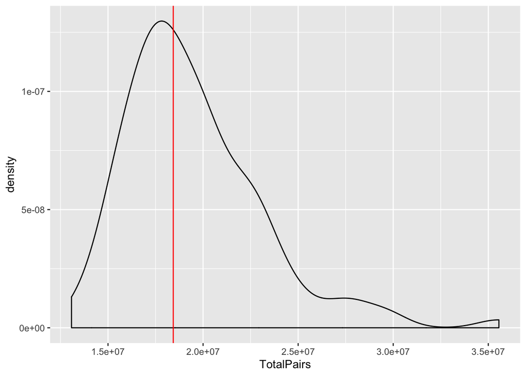

```r
ggplot(data=sgDF) +
  geom_density(aes(x=TotalPairs)) +
  geom_vline(xintercept = sgDF$TotalPairs[sgDF$SampleID=="1060435348"], color="red")
```

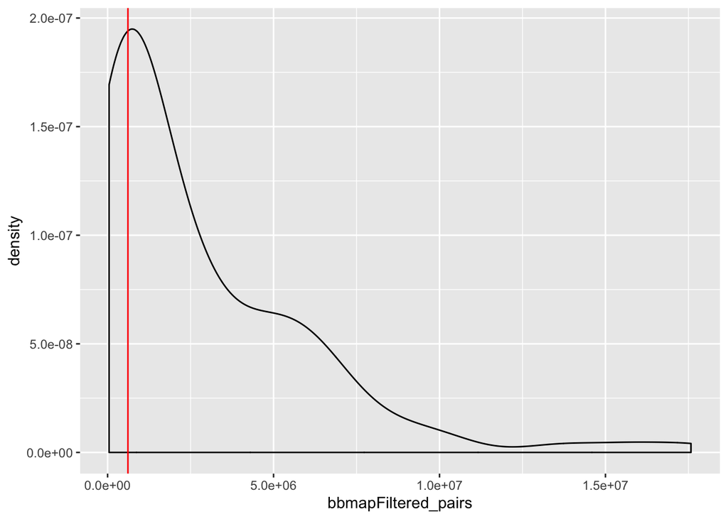

```r
ggplot(data=sgDF) +
  geom_density(aes(x=bbmapFiltered_pairs)) +
  geom_vline(xintercept = sgDF$bbmapFiltered_pairs[sgDF$SampleID=="1060435348"], color="red")
```

Relatively low read count in this sample.

### Samples where we lose one variant

First 10508 sample (1050801308) see only C2 with shotgun. G3 (ambiguous) and G1 were see. –we lose G1

```r
#gardnerella found by metaphlan in sample 1050801308
gardVarDF %>%
  filter(SampleID=="1050801308") %>%
  select(SampleID, Var, propGard, Method)
```

```
## # A tibble: 3 x 4
##   SampleID   Var                propGard Method
##   <chr>      <fct>                 <dbl> <chr>
## 1 1050801308 G1: Clades 3/4        0.799 V4 region 16S amplicon
## 2 1050801308 G3: indetereminant    0.201 V4 region 16S amplicon
## 3 1050801308 Clade 2               1     Shotgun
```

```r
#percent Gardnerella in this sample
mDF %>%
  select(SampleID, Gardnerella_vaginalis) %>%
  filter(SampleID=="1050801308")
```

```
## # A tibble: 1 x 2
##   SampleID   Gardnerella_vaginalis
##   <chr>                      <dbl>
## 1 1050801308               0.00234
```

```r
#read depth of these samples
sgDF %>%
  filter(SampleID=="1050801308") %>%
  select(SampleID, TotalPairs, bbmapFiltered_pairs, PctHuman, finalPctHuman_po)
```

```
## # A tibble: 1 x 5
##   SampleID   TotalPairs bbmapFiltered_pairs PctHuman finalPctHuman_po
##   <chr>           <dbl>               <dbl>    <dbl>            <dbl>
## 1 1050801308   17902425              984805    0.473            0.937
```

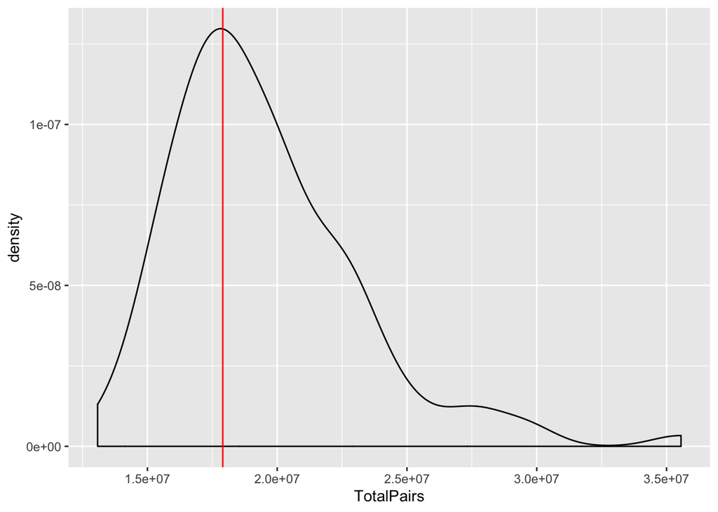

```r
ggplot(data=sgDF) +
  geom_density(aes(x=TotalPairs)) +
  geom_vline(xintercept = sgDF$TotalPairs[sgDF$SampleID=="1050801308"], color="red")
```

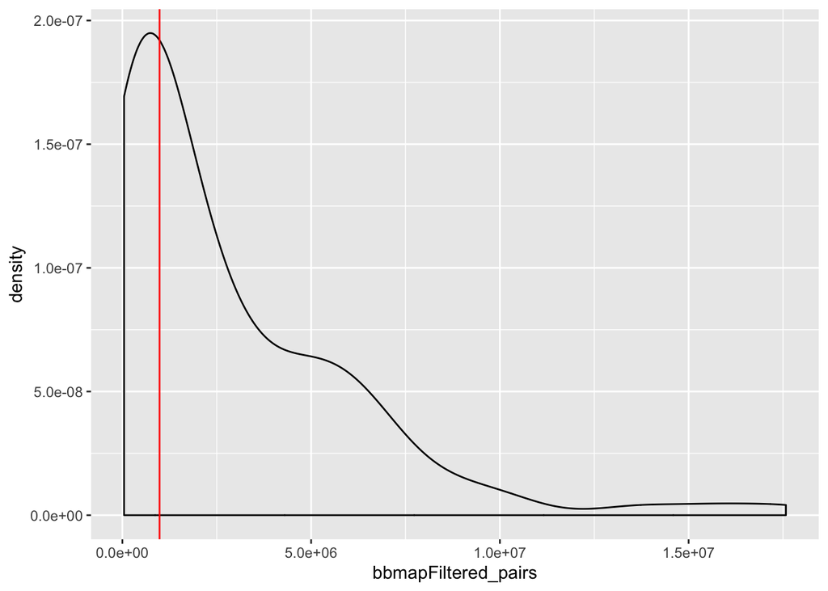

```r
ggplot(data=sgDF) +
  geom_density(aes(x=bbmapFiltered_pairs)) +
  geom_vline(xintercept = sgDF$bbmapFiltered_pairs[sgDF$SampleID=="1050801308"], color="red")
```

Third sample 10629 (1062901318) We lose G5 (ie don’t see C6, but G5 was the least abundant variant in this sample.

```r
#gardnerella found by metaphlan in sample 1062901318
gardVarDF %>%
  filter(SampleID=="1062901318") %>%
  select(SampleID, Var, propGard, Method)
```

```
## # A tibble: 10 x 4
##    SampleID   Var                propGard Method
##    <chr>      <fct>                 <dbl> <chr>
##  1 1062901318 G1: Clades 3/4      0.768   V4 region 16S amplicon
##  2 1062901318 G2: Clades 1/2      0.181   V4 region 16S amplicon
##  3 1062901318 G3: indetereminant  0.0238  V4 region 16S amplicon
##  4 1062901318 G4: Clade 5         0.0194  V4 region 16S amplicon
##  5 1062901318 G5: Clade 6         0.00792 V4 region 16S amplicon
##  6 1062901318 Clade 1             0.136   Shotgun
##  7 1062901318 Clade 2             0.00524 Shotgun
##  8 1062901318 Clade 3             0.0681  Shotgun
##  9 1062901318 Clade 4             0.707   Shotgun
## 10 1062901318 Clade 5             0.0838  Shotgun
```

```r
#percent Gardnerella in this sample
mDF %>%
  select(SampleID, Gardnerella_vaginalis) %>%
  filter(SampleID=="1062901318")
```

```
## # A tibble: 1 x 2
##   SampleID   Gardnerella_vaginalis
##   <chr>                      <dbl>
## 1 1062901318                 0.645
```

```r
#read depth of these samples
sgDF %>%
  filter(SampleID=="1062901318") %>%
  select(SampleID, TotalPairs, bbmapFiltered_pairs, PctHuman, finalPctHuman_po)
```

```
## # A tibble: 1 x 5
##   SampleID   TotalPairs bbmapFiltered_pairs PctHuman finalPctHuman_po
##   <chr>           <dbl>               <dbl>    <dbl>            <dbl>
## 1 1062901318   19946512              996289    0.480            0.943
```

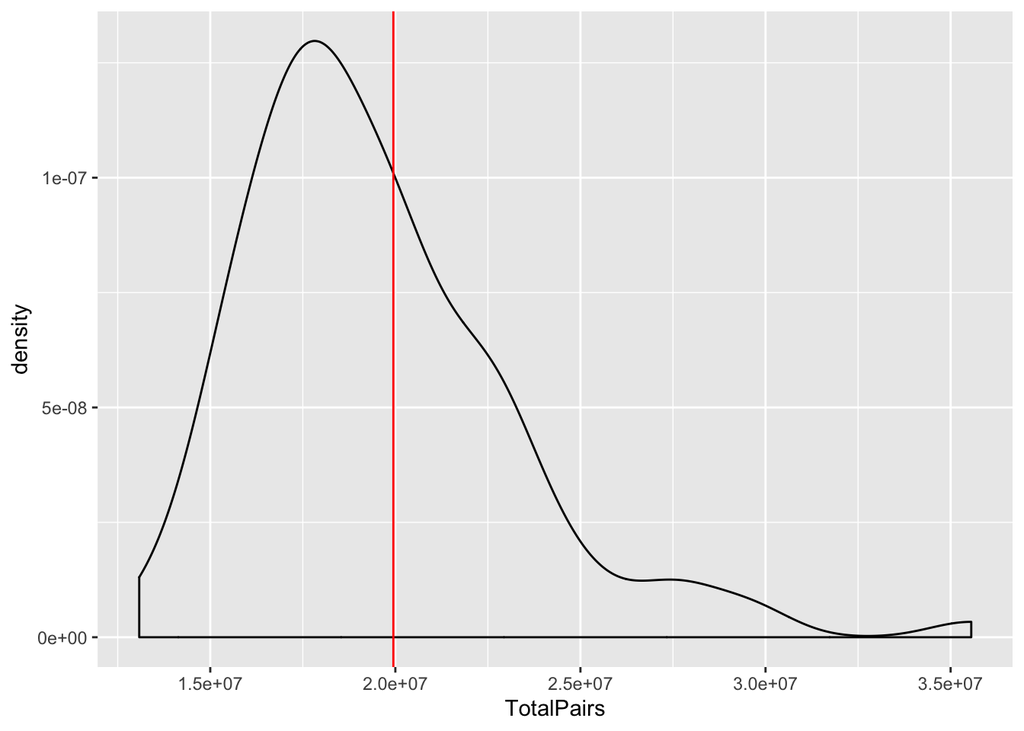

```r
ggplot(data=sgDF) +
  geom_density(aes(x=TotalPairs)) +
  geom_vline(xintercept = sgDF$TotalPairs[sgDF$SampleID=="1062901318"], color="red")
```

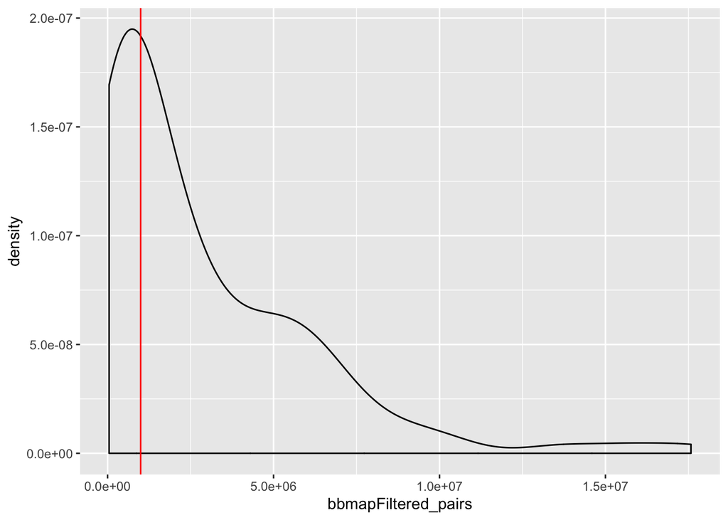

```r
ggplot(data=sgDF) +
  geom_density(aes(x=bbmapFiltered_pairs)) +
  geom_vline(xintercept = sgDF$bbmapFiltered_pairs[sgDF$SampleID=="1062901318"], color="red")
```

Second 10627 sample (1062701298) G3 looks like C1, C2, and C6 – we haven’t seen a G3 variant in C6 before, but it is not impossible as we only have 1 reference strain in this clade at present.

# Reads cutoff?:

```r
sgGardDF$n %>%
  summary
```

```
##    Min. 1st Qu.  Median    Mean 3rd Qu.    Max.
##     1.0    12.5    81.0   570.7   328.0 15924.0
```

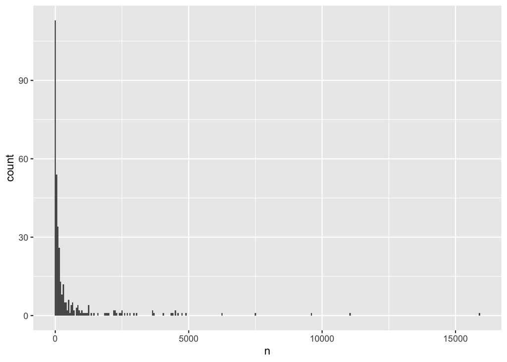

```r
sgGardDF %>%
  group_by(SampleID) %>%
  summarise(nClades=n()) %>%
  right_join(sgGardDF, by="SampleID") %>%
  ggplot(aes(x=n, fill=nClades)) +
  geom_histogram(binwidth = 50)
```

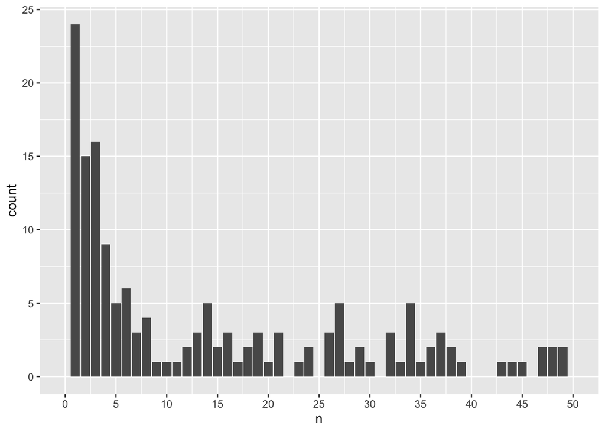

```r
sgGardDF %>%
  group_by(SampleID) %>%
  summarise(nClades=n()) %>%
  right_join(sgGardDF, by="SampleID") %>%
  ggplot(aes(x=n, fill=nClades)) +
  geom_bar() +
  scale_x_continuous(limits=c(0,50), breaks=seq(0,50,by=5))
```

range of reads per clade is 1 to ~16,000. A large portion are below 5 reads per clade.

Cases of one read per clade:

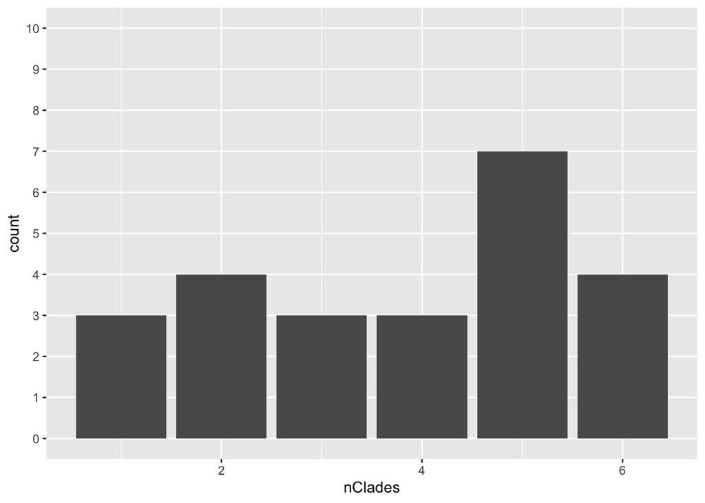

```r
sgGardDF %>%
  group_by(SampleID) %>%
  summarise(nClades=n()) %>%
  right_join(sgGardDF, by="SampleID") %>%
  ungroup() %>%
  filter(n==1) %>%
  ggplot(aes(x=nClades)) +
  geom_bar() +
  scale_y_continuous(limits = c(0,10), breaks = seq(0,10,by=1), minor_breaks = NULL)
```

Only 3 samples have one read of one clade.

# Testing Absolute Abundance

## Number taxa vs filtered read count

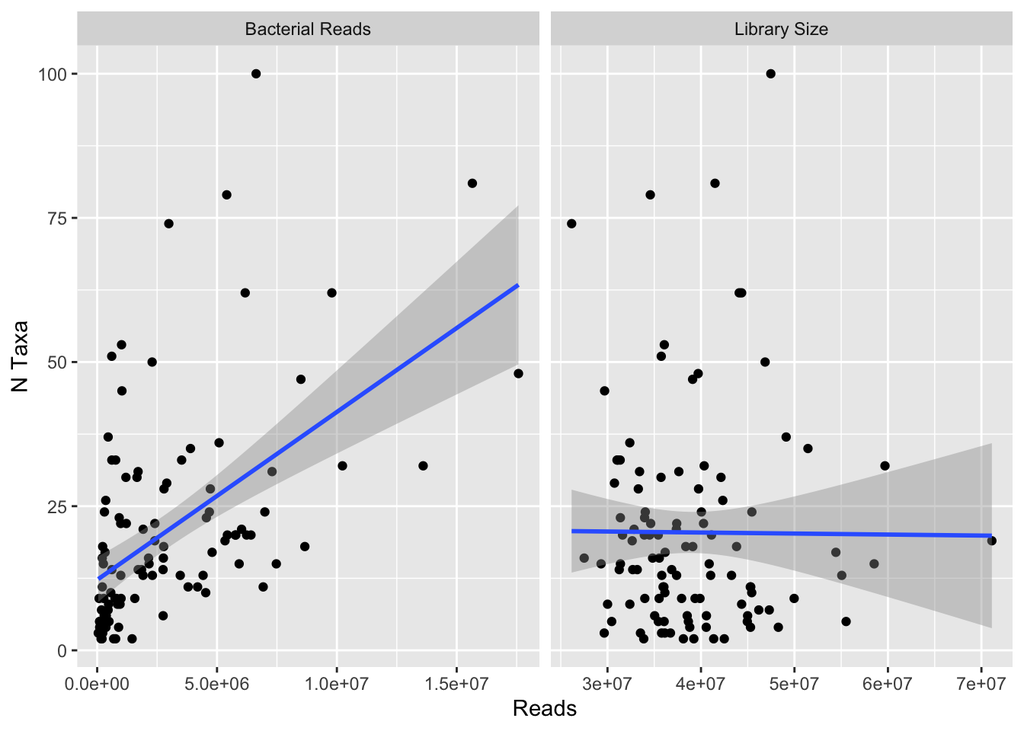

```r
mDF %>%
  gather("Taxon", "Abundance", c(2:ncol(.))) %>%
  filter(Abundance>0) %>%
  group_by(SampleID) %>%
  summarise(nTaxa=n_distinct(Taxon)) %>%
  left_join(sgDF[,c("SampleID", "TotalReads", "bbmapFiltered_pairs")], by="SampleID") %>%
  gather("measure", "readCount", c(TotalReads, bbmapFiltered_pairs)) %>%
  mutate(measure=case_when(measure=="TotalReads"~"Library Size",
                           measure=="bbmapFiltered_pairs"~"Bacterial Reads")) %>%
  ggplot(aes(x=readCount, y=nTaxa)) +
    geom_point() +
    geom_smooth(method="lm") +
    facet_wrap(~measure, scales="free_x") +
    labs(x="Reads", y="N Taxa")
```

```r
mDF %>%
  gather("Taxon", "Abundance", c(2:ncol(.))) %>%
  filter(Abundance>0) %>%
  group_by(SampleID) %>%
  summarise(nTaxa=n_distinct(Taxon)) %>%
  left_join(sgDF[,c("SampleID", "finalPctHuman_po", "finalPctHuman_all", "bbmapFiltered_pairs", "bbmapFiltered_sngl")], by="SampleID") %>%
  lm(data=., nTaxa~bbmapFiltered_pairs) %>%
  summary
```

```
##
## Call:
## lm(formula = nTaxa ~ bbmapFiltered_pairs, data = .)
##
## Residuals:
##     Min      1Q  Median      3Q     Max
## -21.389  -9.265  -5.611   5.673  68.470
##
## Coefficients:
##                      Estimate Std. Error t value Pr(>|t|)
## (Intercept)         1.223e+01  2.006e+00   6.094 1.85e-08 ***
## bbmapFiltered_pairs 2.911e-06  4.601e-07   6.328 6.23e-09 ***
## ---
## Signif. codes:  0 '***' 0.001 '**' 0.01 '*' 0.05 '.' 0.1 ' ' 1
##
## Residual standard error: 15.81 on 105 degrees of freedom
## Multiple R-squared:  0.2761, Adjusted R-squared:  0.2692
## F-statistic: 40.04 on 1 and 105 DF,  p-value: 6.227e-09
```

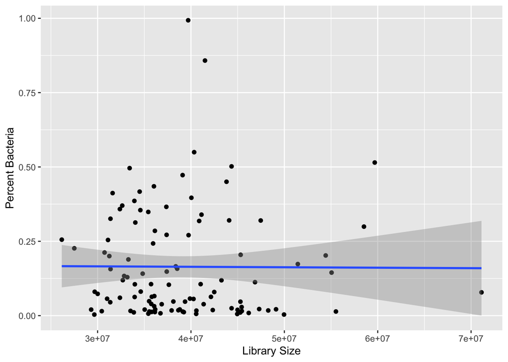

```r
sgDF %>%
  ggplot(aes(x=TotalReads, y=(1-finalPctHuman_po))) +
  geom_point() +
  geom_smooth(method="lm") +
  labs(x="Library Size", y="Percent Bacteria")
```

## Richness vs percent bacteria

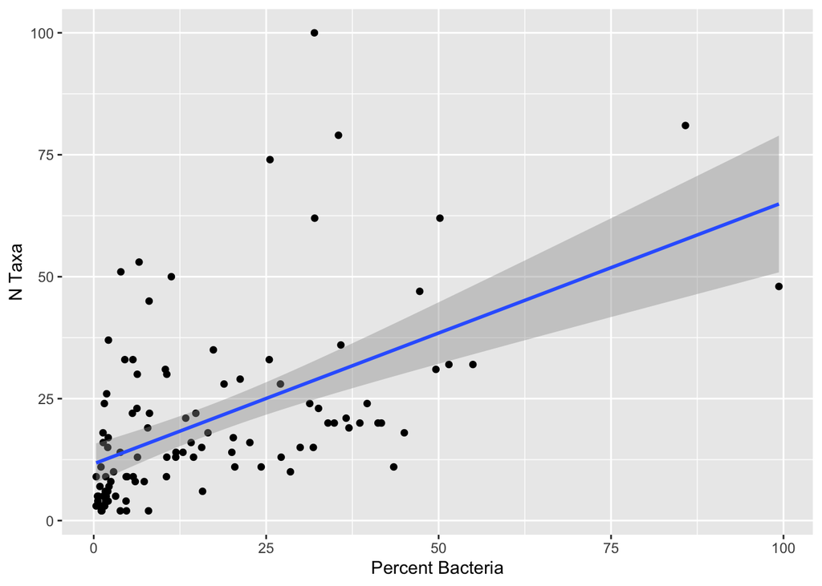

```r
mDF %>%
  gather("Taxon", "Abundance", c(2:ncol(.))) %>%
  filter(Abundance>0) %>%
  group_by(SampleID) %>%
  summarise(nTaxa=n_distinct(Taxon)) %>%
  left_join(sgDF[,c("SampleID", "finalPctHuman_po", "finalPctHuman_all", "bbmapFiltered_pairs", "bbmapFiltered_sngl")], by="SampleID") %>%
  ggplot(aes(x=(1-finalPctHuman_po)*100, y=nTaxa)) +
    geom_point() +
    geom_smooth(method="lm") +
    labs(x="Percent Bacteria", y="N Taxa")
```

```r
mDF %>%
  gather("Taxon", "Abundance", c(2:ncol(.))) %>%
  filter(Abundance>0) %>%
  group_by(SampleID) %>%
  summarise(nTaxa=n_distinct(Taxon)) %>%
  left_join(sgDF[,c("SampleID", "finalPctHuman_po", "finalPctHuman_all", "bbmapFiltered_pairs", "bbmapFiltered_sngl")], by="SampleID") %>%
  mutate(pct_bacteria=1-finalPctHuman_po) %>%
  lm(data=., nTaxa~pct_bacteria) %>%
  summary
```

```
##
## Call:
## lm(formula = nTaxa ~ pct_bacteria, data = .)
##
## Residuals:
##     Min      1Q  Median      3Q     Max
## -23.957  -9.085  -5.484   5.398  71.210
##
## Coefficients:
##              Estimate Std. Error t value Pr(>|t|)
## (Intercept)    11.632      2.046   5.685 1.18e-07 ***
## pct_bacteria   53.630      8.325   6.442 3.63e-09 ***
## ---
## Signif. codes:  0 '***' 0.001 '**' 0.01 '*' 0.05 '.' 0.1 ' ' 1
##
## Residual standard error: 15.73 on 105 degrees of freedom
## Multiple R-squared:  0.2833, Adjusted R-squared:  0.2764
## F-statistic:  41.5 on 1 and 105 DF,  p-value: 3.635e-09
```

# Make absolute abundance

```r
# mDFabsolute <- mDF %>%
#   left_join(sgDF[,c("SampleID", "finalPctHuman_po")], by="SampleID") %>%
#   select(SampleID, finalPctHuman_po, everything()) %>%
#   mutate_at(c(3:ncol(.)), ~.x/finalPctHuman_po)
# save(mDFabsolute, file = "./metaphlanAbsoluteAbundances.Rdata")
```